# Wahlfälschung Georgien? Urnen-Vergleich Deutschland

## Germany

```r
library(tidyverse)
# Germany
B_all <- read_csv2("~/Documents/data/bundeswahlleiter/btw21_wbz/btw21_wbz_ergebnisse.csv") |> na.omit()
B <- B_all |>
# Exploration yields that Wahlkreis, Gemeinde, `Gemeinde Name`,Wahlbezirk, Bezirksart is a unique ID
  filter(Bezirksart == "0") |>
  mutate(.before = Wahlkreis,
         `Total Voters` =  (`Wahlberechtigte ohne Sperrvermerk (A1)` + `Wählende mit Wahlschein (B1)`),
         Turnout = `Wählende (B)`,
         `Turnout Fraction` = Turnout / `Total Voters`,
         CDU = E_CDU / E_Gültige,
         CSU = E_CSU / E_Gültige,
         Union = if_else(CSU == 0, CDU, CSU),
         LINKE = `E_DIE LINKE` / E_Gültige,
         GRÜNE = E_GRÜNE / E_Gültige,
         SPD = E_SPD / E_Gültige,
         AfD = E_AfD / E_Gültige,
         FDP = E_FDP / E_Gültige
  ) |>
  filter(`Total Voters` > 0, Turnout > 0)
ParteiFarben <- tibble(Partei = c("SPD","Union","GRÜNE","FDP","LINKE","BIW","AfD", "Turnout Fraction"),
                       Farbe = c("#ff0000", "#000000", "#009933","#e6e600","#990033", "#ff9900", "#0099ff", "gray"),
                       Textfarbe = c("white","white","white","black","white","black","white","white"))
TotalVoters <- B$`Total Voters`
Turnout <- B$Turnout
```

Reading in precinct data from Germany Bundestag election 2021 provided by the Bundeswahlleiterin. We use only precincts for onsite voting and ignore precincts for postal votes. For these precincts we computed the total voters by summing those voters who were eligible in that district and not registered for postal voting plus those who came in that precinct on site with their postal letter certificate and were thus allowed to vote. These are 64796 precincts. The median number of total voters are 555 the first quartile is 358 the third 750. (Maximum and minimum are 50 and 5512.) The total eligible voters over all are 36.849.874.

For each precint we also record the turnout, the turnout as a fraction of total voters and the fraction of votes fo the major parties at the turnout. The median turnout is 358 the first quartile is 237 the third 480. (Maximum and minimum are 40 and 2056.) The total turnout over all is 23.872.540.

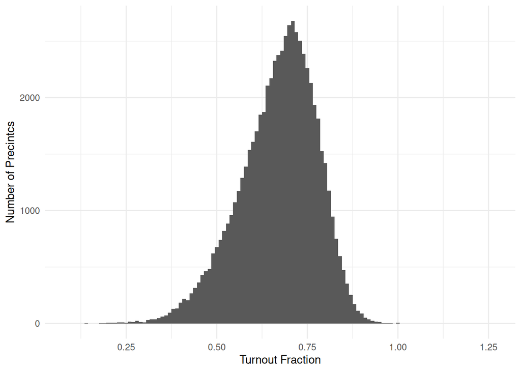

```r
B |> ggplot() +
  aes(`Turnout Fraction`) +
  geom_histogram(binwidth = 0.01) +
  labs(y = "Number of Precintcs") +
  theme_minimal()
```

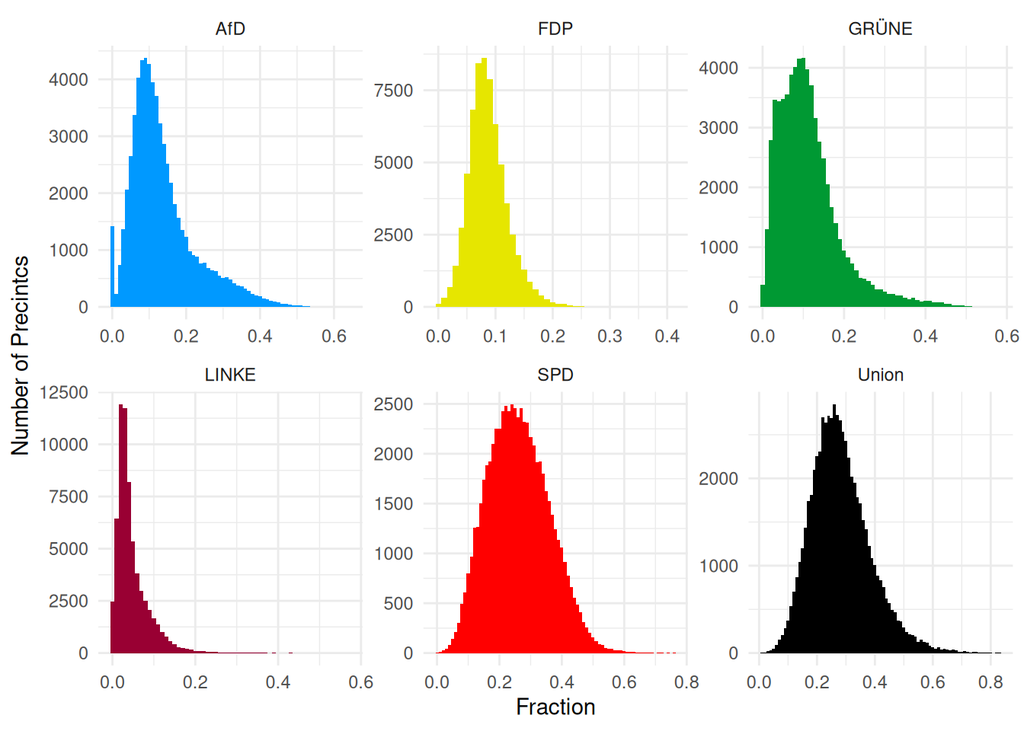

```r
B_long <- B |>
  select(Union, SPD, GRÜNE, FDP, LINKE, AfD, `Turnout Fraction`, Turnout) |>
  pivot_longer(c(Union, LINKE, SPD, GRÜNE, FDP, AfD), names_to = "Party", values_to = "Fraction")
B_long |> left_join(ParteiFarben, by = join_by(Party == Partei)) |>
  ggplot() +
  aes(Fraction, fill = Farbe) +
  geom_histogram(binwidth = 0.01) +
  facet_wrap(~Party, scales = "free") +
  scale_fill_identity() +
  labs(y = "Number of Precintcs") +
  theme_minimal()
```

The following shows scatter plots where each precints is a point in the space of turnout fraction and party fraction at the turnout.

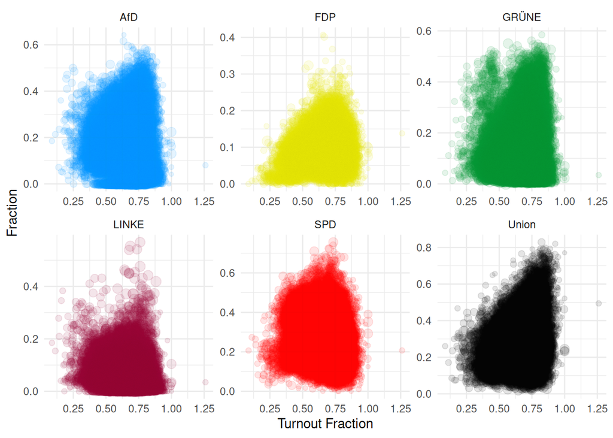

```r
B_long |> left_join(ParteiFarben, by = join_by(Party == Partei)) |>
  ggplot() +
  aes(`Turnout Fraction`, Fraction, color = Farbe, size = Turnout) +
  geom_point(alpha = 0.1) +
  facet_wrap(~Party, scales = "free") +
  scale_color_identity() +
  theme_minimal() +
  guides(size = "none")
```

## Georgia

```r
# Georgia
statisticCESCO <- read_csv("Rigged-Elections-of-Georgia-2024/Statistics of CESKO.csv") |>
  separate_wider_delim(Alias, delim = '.',names = c("Georgia", "District", "Percinct"), cols_remove = FALSE) |>
  mutate(`Turnout Fraction` = Turnout / `Total Voters`,
         GD = `GD vote count`/Turnout)
R <- readxl::read_xlsx("Rigged-Elections-of-Georgia-2024/Final-Source.xlsx") |>
  rename(Party = name_trimmed)
R_precincts <- R |> summarize(Turnout = sum(votes), .by = alias)
R_majorparties <- R |>
  summarize(votes = sum(votes), .by = Party) |>
  mutate(Fraction = votes/sum(votes)) |>
  filter(Fraction >= 0.05) |>
  mutate(Party_en =
           c("Gakharia", "Georgian Dream", "National Movement", "Strong Georgia (Lelo)", "Coalition for change"),
         Farbe = c("#4a2a75","#345099","#d1001d", "#edaf26", "#226049"))
```

We read data from this repository: https://github.com/RocinantEL/Rigged-Elections-of-Georgia-2024/tree/main

The median turnout (sum over all parties, no records on invalid votes) is 652 the first quartile is 320 the third 929.75. (Maximum and minimum are 23 and 2229.) The total turnout over all is 2.076.728.

The file `Statistics of CESKO.csv` contains data for most precincts with same IDs and in `Final-Source.xlsx`. However, there is only data about 3044 precincts.[^1]

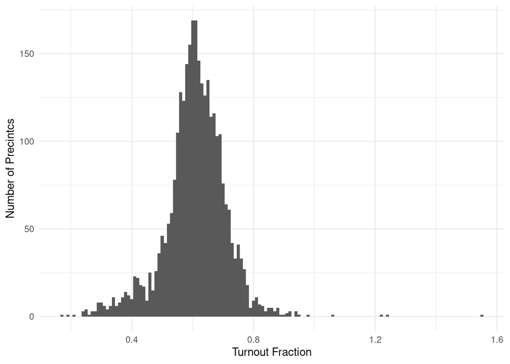

```r
G <- R |>
  left_join(statisticCESCO |>
              select(alias = Alias, Turnout_CESCO = Turnout, `Total Voters`, `GD vote count`, `Turnout Fraction`),
            by = join_by(alias)) |>
  left_join(R_precincts, by = join_by(alias)) |>
  left_join(R_majorparties |> select(Party, Party_en, Farbe), by = join_by(Party)) |>
  mutate(Fraction = votes / Turnout)
G |>
  select(alias,`Turnout Fraction`) |>
  distinct() |>
  ggplot() +
  aes(`Turnout Fraction`) +
  geom_histogram(binwidth = 0.01) +
  labs(y = "Number of Precintcs") +
  theme_minimal()
```

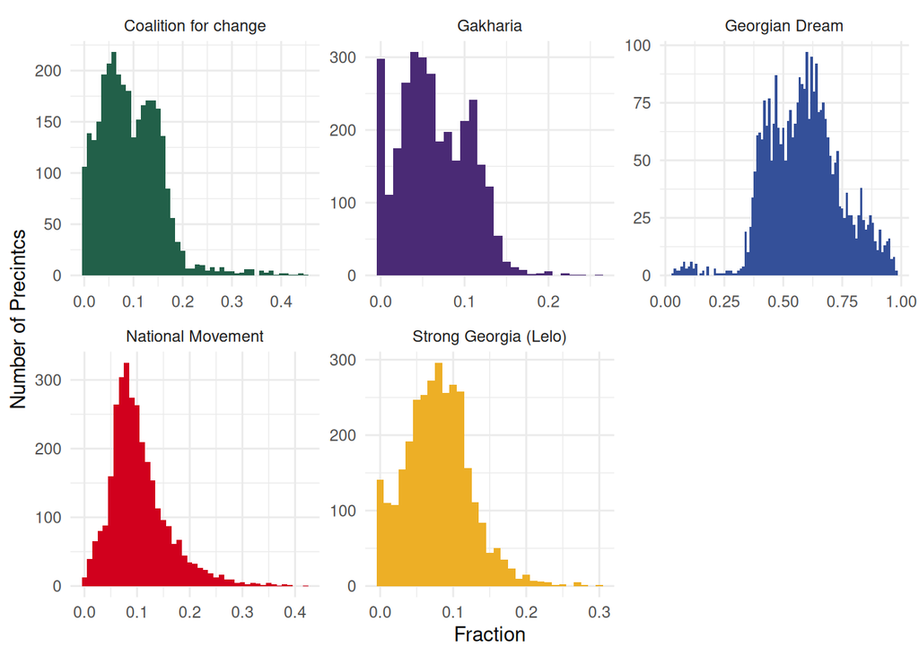

```r
G |> filter(Party_en %in% R_majorparties$Party_en) |>
  ggplot() +
  aes(Fraction, fill = Farbe) +
  geom_histogram(binwidth = 0.01) +
  facet_wrap(~Party_en, scales = "free") +
  scale_fill_identity() +
  labs(y = "Number of Precintcs") +
  theme_minimal() +
  guides(fill = "none", size = "none")
```

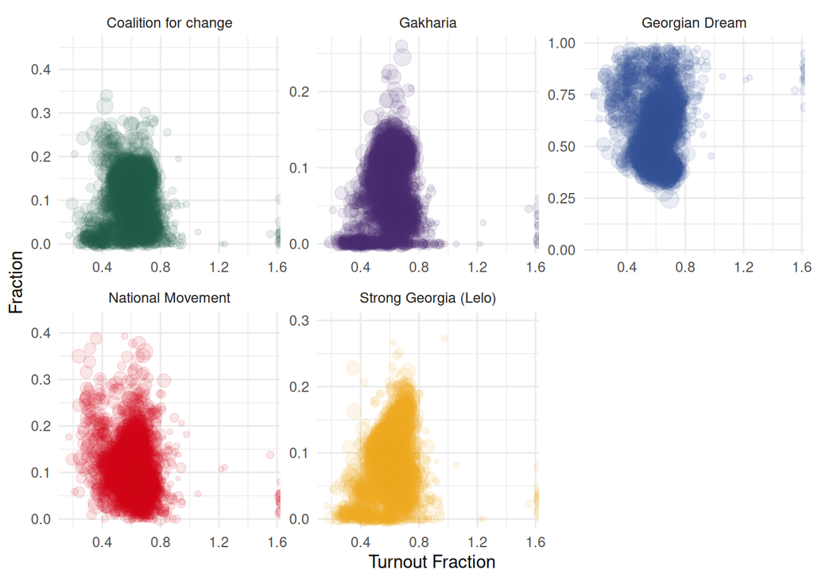

```r
G |>  filter(Party_en %in% R_majorparties$Party_en) |>
  ggplot() +
  aes(`Turnout Fraction`, Fraction, color = Farbe, size = Turnout) +
  geom_point(alpha = 0.1) +
  facet_wrap(~Party_en, scales = "free") +
  scale_color_identity() +
  theme_minimal() +
  guides(color = "none", size = "none")
```

```r
# G <- read_csv("Rigged-Elections-of-Georgia-2024/electoraldistrictsprb.csv") |>
#   select(District = `...1`,
#          `Georgian Dream` = `41`,
#          Gakharia = `25`,
#          `National Movement` = 5,
#          `Coalition for change` = `4`,
#          Lelo = `9`) |>
#   mutate(across(`Georgian Dream`:Lelo, \(x) parse_number(x)/100 ))
# election_size <- read_csv("Rigged-Elections-of-Georgia-2024/election_size.csv")
# realdist <- read_csv("Rigged-Elections-of-Georgia-2024/realdist5%.csv") |> select(1:2) |> slice(1:21)
```

```r
# B_long |>
#   summarize(mean = mean(Fraction, na.rm = T),
#             sd = sd(Fraction, na.rm = T),
#             .by = c(Party)) |>
#   knitr::kable()
```

## Footnotes

[^1]: In `Final-Source.xlsx` precinct 00.22.69 is missing, however `Statistics of CESKO.csv` records it as having zero Turnout. In `Statistics of CESKO.csv` the following 67 are missing: 00.87.01, 00.87.02, 00.87.03, 00.87.04, 00.87.05, 00.87.06, 00.87.07, 00.87.08, 00.87.09, 00.87.10, 00.87.11, 00.87.12, 00.87.13, 00.87.14, 00.87.15, 00.87.16, 00.87.17, 00.87.18, 00.87.19, 00.87.20, 00.87.21, 00.87.22, 00.87.23, 00.87.24, 00.87.25, 00.87.26, 00.87.27, 00.87.28, 00.87.29, 00.87.30, 00.87.31, 00.87.32, 00.87.33, 00.87.34, 00.87.35, 00.87.36, 00.87.37, 00.87.38, 00.87.39, 00.87.40, 00.87.41, 00.87.42, 00.87.43, 00.87.44, 00.87.45, 00.87.46, 00.87.47, 00.87.48, 00.87.49, 00.87.50, 00.87.51, 00.87.52, 00.87.53, 00.87.54, 00.87.55, 00.87.56, 00.87.57, 00.87.58, 00.87.59, 00.87.60, 00.87.61, 00.87.62, 00.87.63, 00.87.64, 00.87.65, 00.87.66, 00.87.67. These are all precincts of district 87. The other districts are numbered from 1 to 84.